# Plot the expression of Pi starvaiton induced genes relevant for oxidative stress, in *C. glabrata*

## Analysis

### Plotting *C. glabrata* time course

```r
myGenesPlot <- function(genes = "CAGL0B02475g", names = "PMU2") {
  # this function takes in the read count matrix (normalized and transformed) and a list of gene IDs
  # and plots the values stratified by genotype and timepoint
  if(any(!genes %in% rownames(se))){
    print("The following genes are not included in the experiment. Check to make sure that the gene names are correct.")
    setdiff(genes, rownames(se))
    stop("Gene names not included in the experiment")
  }

  if(!is.null(names(genes))){
    names = names(genes)
  }
  else if(length(genes) != length(names)){
    stop("length of 'genes' must equal length of 'names'")
  }


  # construct tibble for plotting
  dat <- t(assay(se[genes,])) %>% as_tibble(rownames = NA) %>% rownames_to_column(var = "sample") # subset the expression matrix
  tb <- colData(se) %>% as_tibble(rownames = NA) %>%
    rownames_to_column(var = "sample") %>%
    select(sample, Genotype, Timepoint) %>%
    left_join(dat, by = "sample") %>%
    pivot_longer(cols = starts_with("CAGL"), names_to = "gene", values_to = "log2 cpm") %>%
    left_join(tibble(gene = genes, name = names), by = "gene")

  p <- ggplot(tb, aes(x = Timepoint, y = `log2 cpm`)) +
    geom_point() + geom_smooth(method = "loess", formula = y ~ x, aes(x = as.numeric(Timepoint), y = `log2 cpm`)) +
    xlab("") + ylab("log2 count per million") + facet_wrap(~paste(gene, name, sep = ":"), scale = "free_y") +
    theme_bw(base_size = 12) +
    theme(axis.text.x = element_text(angle = 45, size = rel(0.75), hjust = 1),
          axis.text.y = element_text(size = rel(0.75)))
  return(p)
}
```

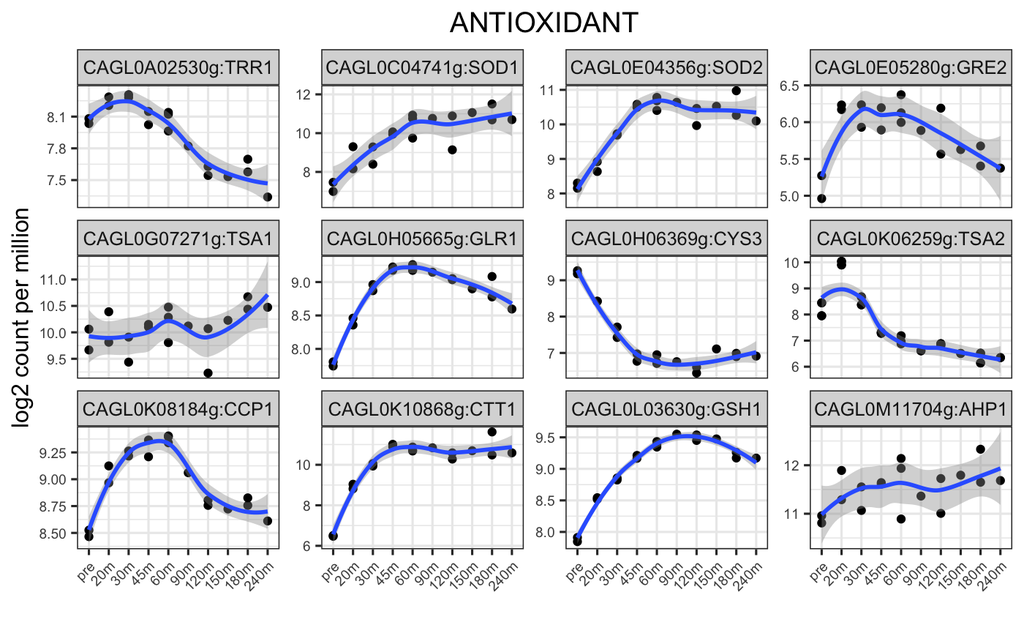

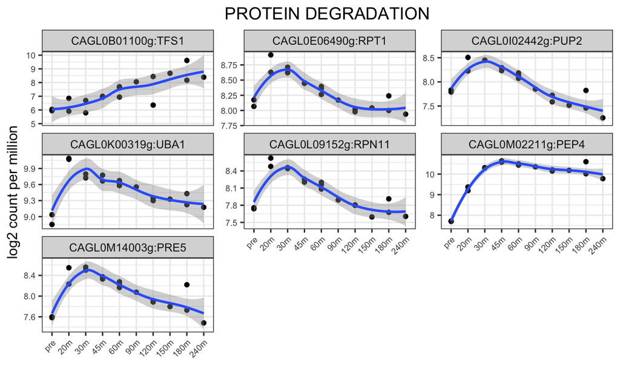

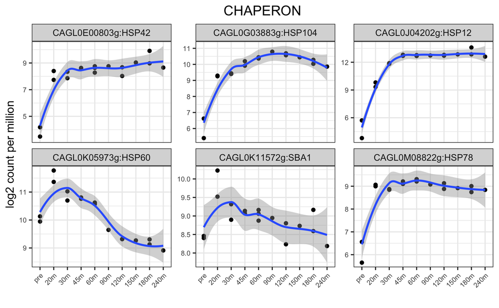

```r
group <- c("antioxidant", "protein degradation", "chaperon")
categories <- lapply(group, function(x){
  test <- cgla.list %>%
    filter(category == x) %>%
    select(ScerName, CglaID) %>%
    filter(!is.na(CglaID)) %>%
    deframe()
})
names(categories) <- group
categories$antioxidant <- c(categories$antioxidant, CTT1 = "CAGL0K10868g", TSA2 = "CAGL0K06259g")
for (i in seq_along(categories)){
  p <- myGenesPlot(categories[[i]])
  print(p + ggtitle(str_to_upper(group[i])) + theme(plot.title = element_text(hjust = 0.5)))
}
```

### Compare with *S. cerevisiae* -Pi at 1hr

To compare OSR genes under phosphate starvation in *C. glabrata* vs in *S. cerevisiae*, I downloaded Xu’s 2011 data, which was measured using two-color microarray at 1hr post starvation. In the future I plan to use Gurvich 2017, which contains the time course data but requires more processing.

First, we need to assemble the dataset. The idea is to calculate the log2FC between 1hr and pre-stress time points from the *C. glabrata* dataset. Later we will merge it with the *S. cerevisiae* data. The final data should include `Species | Name | ID | log2FC`, in which `Name` is always from *S. cerevisiae* and `ID` from the respective species.

```r
tmp <- assay(se[, se$Timepoint %in% c("pre", "60m")])
colnames(tmp) <- c("pre.1","pre.2","60m.1","60m.2","60m.3")
cgla.1hr <- as_tibble(tmp, rownames = "CglaID") %>%
  mutate(
    base = (pre.1 + pre.2)/2,
    m60.1 = `60m.1` - base,
    m60.2 = `60m.2` - base,
    m60.3 = `60m.3` - base
  ) %>%
  select(CglaID, starts_with("m60")) %>%
  pivot_longer(m60.1:m60.3, names_to = NULL, values_to = "log2FC")
```

Note that this calculation “hides” the variation in the pre-stress sample by using only the mean level of expression. As a result, the three replicate values are actually an underestimate of the amount of variation in *C. glabrata*. By contrast, the *S. cerevisiae* dataset were measured using two-color microarrays, which are naturally paired – it always measures the ratio between the stressed and unstressed samples. That being said, I don’t think the magnitude of the underestimation is going to be large, given the tight correlations between the biological replicates. And the overall conclusion from this figure is not going to change – a group of OSR genes are strongly induced in *C. glabrata* but not in *S. cerevisiae*

With the Cgla data calculated, we can write a function that takes a list of *S. cerevisiae* gene names as input and plot the logFC in both species. change the fond size and style of myCompare mycomare_rl: remove the legends

```r
myCompare <- function(genes = "YML123C"){
  # ------
  # this function is used to extract and assemble the expression data from the two species
  # it returns a tibble that can be used for plotting
  # ------
  # check gene names against the S. cerevisiae microarray annotation
  scerArray <- rowData(gse)$ORF
  names(scerArray) <- rowData(gse)$Name
  if(all(!genes %in% scerArray)){
    stop("Check ORF names. None are present in the annotation file.")
  }else if(any(!genes %in% scerArray)){
    print("The following S. cerevisiae genes are not included on the microarray chip.")
    print(setdiff(genes, scerArray))
  }else if(any(!genes %in% re.scToCg$ScerID)){
    # additionally check if the genes have a C. glabrata ortholog
    print("The following S. cerevisiae genes do not have a C. glabrata ortholog.")
    print(setdiff(genes, re.scToCg$ScerID))
  }
  # construct a gene set tibble that includes orthologous gene names in both species
  geneSet <- rowData(gse) %>%
    as_tibble(rownames = NULL) %>%
    filter(ORF %in% genes) %>%
    select(ScerID = ORF) %>%
    left_join(re.scToCg, by = "ScerID")

  # extract Scer data
  probes <- rowData(gse1) %>% as_tibble() %>% filter(ORF %in% geneSet$ScerID) %>% select(ID, ORF)
  scerDat <- assay(gse1)[probes$ID,,drop=FALSE] %>%
    as_tibble(rownames = "ID") %>%
    left_join(probes, by = "ID") %>%
    pivot_longer(cols = starts_with("GSM"), names_to = NULL, values_to = "log2FC") %>%
    select(ScerID = ORF, log2FC) %>%
    left_join(select(geneSet, ScerID, ScerName), by = "ScerID") %>%
    select(ScerName, ID = ScerID, log2FC)
  # extract Cgla data
  cglaDat <- cgla.1hr %>%
    filter(CglaID %in% na.omit(geneSet$CglaID)) %>%
    left_join(select(geneSet, CglaID, ScerName), by = "CglaID") %>%
    select(ScerName, ID = CglaID, log2FC)
  Dat <- bind_rows(`S. cerevisiae` = scerDat, `C. glabrata` = cglaDat, .id = "species") %>%
    # sort the gene list by Cgla induction mean
    mutate(ScerName = forcats::fct_reorder(ScerName, log2FC, mean, .desc = TRUE))
  return(Dat)
}

myPlotExn <- function(dat, col = c("S. cerevisiae" = "gray30", "C. glabrata" = "orange2"),
                      #fill = c("S. cerevisiae" = "#61328C", "C. glabrata" = "#5B9A3D"),
                      fill = c("S. cerevisiae" = "gray60", "C. glabrata" = "#FBB4AE"),
                      font_size = 16, legend = TRUE, grid = FALSE)
{
  ## -------
  ## this function creates a reproducible plot allowing flexibility in color and legend
  geoms <- list(
    geom_bar(aes(fill = species), stat = "summary", fun = "mean",width = 0.8,
             color = "grey20", linewidth = 1, position = position_dodge(0.9)),
    geom_point(aes(color = species), position = position_dodge(0.9), size = 1),
    geom_hline(yintercept = 0, linetype = 1, color = "gray20"),
    geom_hline(yintercept = 1, linetype = 2, color = "gray50"),
    scale_color_manual(values = col, guide = NULL),
    scale_fill_manual("Species", values = fill),
    labs(x = expression(paste(italic("S. cerevisiae"), " gene names")),
         y = "log2 Fold Change"),
    theme_bw(base_size = font_size),
    theme(legend.title = element_blank(),
          legend.text = element_text(face = 3),
          legend.position = c(0.7, 0.8),
          legend.background = element_blank(),
          axis.text.y = element_text(size = rel(1)),
          axis.text.x = element_text(angle = 45, hjust = 1, size = rel(0.9)),
          axis.title = element_text(size = rel(1)),
          axis.title.x = element_blank(),
          plot.title = element_text(size = rel(1.5))),
    if(!legend) theme(legend.position = "none"),
    if(!grid) background_grid(major = "none", minor = "none")
  )
  p <- ggplot(dat, aes(x = ScerName, y = log2FC, group = species)) + geoms
  return(p)
}
```

Add the TF into the group

```r
group <- c("antioxidant", "protein degradation", "chaperon","TF")
geneList <- lapply(group, function(x){
  scer.osr %>% filter(category == x) %>% pull(scer.sys)
})
names(geneList) <- group
# add CTA1, PRX1 and TRX3, which are OSR-related and induced in C. glabrata but not in S. cerevisiae
# remove CYS3 and TSA2, both of which appear to be down under -Pi in both species
geneList$antioxidant <- setdiff(c(geneList$antioxidant, "YDR256C", "YBL064C", "YCR083W"),
                                c("YDR453C", "YAL012W"))
geneList$TF <- c("YML007W", "YHR206W", "YMR037C", "YKL062W")
```

Get the dataset for plotting

```r
dat <- lapply(geneList, myCompare)
```

```
[1] "The following S. cerevisiae genes do not have a C. glabrata ortholog."
[1] "YGR088W" "YBR117C" "YCL035C" "YGR209C"
[1] "The following S. cerevisiae genes do not have a C. glabrata ortholog."
[1] "YPL240C" "YAL005C"
```

Save the data as a tsv

```r
dat %>% bind_rows(.id = "category") %>%
  write_tsv("../output/20230510-noPi-1hr-log2FC.tsv")
```

Make individual plots

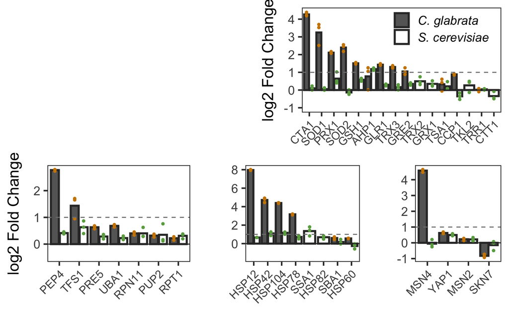

```r
par.fill = c("S. cerevisiae" = "white", "C. glabrata" = "gray40")
par.col = c("S. cerevisiae" = "#6aa84f", "C. glabrata" = "orange3")
p.obj <- list(
  myPlotExn(dat$antioxidant, legend = TRUE, fill = par.fill, col = par.col) + scale_y_continuous(limits = c(-1, NA)),
  myPlotExn(dat$`protein degradation`, legend = FALSE, fill = par.fill, col = par.col) + scale_y_continuous(limits = c(-.5, NA)),
  myPlotExn(dat$chaperon, legend = FALSE, fill = par.fill, col = par.col) + theme(axis.title = element_blank()) +
    scale_y_continuous(limits = c(-1.5, NA)),
  myPlotExn(dat$TF, legend = FALSE, fill = par.fill, col = par.col) + theme(axis.title = element_blank())
)
names(p.obj) <- names(dat)
row1 <- plot_grid(NULL, p.obj$antioxidant)
row2 <- plot_grid(p.obj$`protein degradation`, p.obj$chaperon, p.obj$TF, nrow = 1, align = "hv",
                  rel_widths = c(7, 6, 5))
plot_grid(row1, row2, nrow = 2)
ggsave("../output/20250723-HBZ-compare-gene-exn-multipanel.png", width = 8, height = 6)
```

Jinye’s addition, deprecated

```
for (i in seq_along(geneList)){
  print(group[i])
  if (i == 1) {p <- myCompare(geneList[[i]])}
  else {p <- myCompare_rl(geneList[[i]])}
  print(p + ggtitle(str_to_upper(if (group[i] == "chaperon") {"chaperone"}
  else {group[i]})) + theme(plot.title = element_text(hjust = 0.5)))
  ggsave(paste0("../output/", gsub("-", "", Sys.Date()), "-compare-", group[i], "-gene-induction-in-no-Pi.png"),
         width = 6, height = 4,units = 'in', dpi = 300)
  #ggsave(paste0("../output/", gsub("-", "", Sys.Date()), "-compare-", group[i], "-gene-induction-in-no-Pi.pdf"),
         # width = 6, height = 4)

}
```

Plot for the grant, combining antioxidant, HSP and TF

**update 2023-03-08**

Modified for CERT talk. Dropped out TF and included HSP

```r
# add a fourth category, namely TFs with known roles in oxidative stress response
list.TF <- c(YAP1 = "YML007W", SKN7 = "YHR206W", MSN2 = "YMR037C", MSN4 = "YKL062W")
Dat <- bind_rows(
  list(
    Antioxidant = myCompare(geneList$antioxidant),
    Chaperon = myCompare(geneList$chaperon)#,
    #TF = myCompare(list.TF)
  ),
  .id = "category"
)

ggplot(Dat, aes(x = ScerName, y = log2FC, group = species)) +
    geom_bar(aes(fill = species), stat = "summary", fun = "mean",
             color = "gray20", linewidth = 1, position = position_dodge(0.9)) +
    geom_point(aes(color = species), position = position_dodge(0.9), size = 1) +
    geom_hline(yintercept = 0, linetype = 1, color = "gray20") +
    geom_hline(yintercept = 1, linetype = 2, color = "gray50") +
    scale_color_manual(values = c("S. cerevisiae" = "gray30", "C. glabrata" = "orange2"), guide = NULL) +
    scale_fill_manual("Species", values = c("S. cerevisiae" = "white", "C. glabrata" = "gray40")) +
    labs(x = expression(paste(italic("S. cerevisiae"), " gene names")),
         y = "log2 Fold Change") +
    facet_grid(.~category, space = "free", scales = "free") +
    theme_cowplot() + panel_border() +
    theme(axis.text.x = element_text(angle = 45, hjust = 1, size = rel(0.8)),
          legend.text = element_text(face = 3), legend.position = "top") +
    background_grid(major = "y", minor = "none")
ggsave(paste0("../output/", gsub("-", "", Sys.Date()), "-antioxidant-TF-for-grant.png"), width = 6, height = 4)
```

[output not shown]

### Statistical tests for DGE

The bar plots above clearly show the differences between the two species in terms of OSR gene induction under phosphate starvation in the two species. It is likely that reviewers would ask for statistical test results to support the trend, i.e., whether the gene inductions were significant and whether the differences between species were significant. Below, we perform simple t-tests to provide such support. Note the caveat due to the subtraction of the mean of the pre-stress sample from the 1hr samples in *C. glabrata*, which is expected to slightly decrease the p-values, as the variance would be underestimated. I don’t expect this to have a meaningful impact on the ranking of the genes, given the clear difference in the magnitude of induction between the two species.

First, we need to prepare the data. We would like to get a single dataset with all replicates for each gene in the two species.

```r
dge.dat <- bind_rows(dat, .id = "group")
```

T-test for each gene against the null hypothesis of no differential expression

```r
dge.test <- dge.dat %>% group_by(species, ScerName) %>%
  nest() %>%
  mutate(test = map(data, ~ t.test(.x$log2FC, alternative = "greater")),
         tidied = map(test, tidy)) %>%
  unnest(tidied) %>%
  select(species, ScerName, lfc = estimate, t.stat = statistic, p.value)
dge.test$p.adj <- p.adjust(dge.test$p.value, method = "BH")
dge.test %>% filter(p.adj < 0.05, lfc >= 1) %>% arrange(desc(lfc), p.value)
```

[output not shown]

T-test for each gene against the null hypothesis of less than 1.5 fold induction

```r
dge.test1 <- dge.dat %>% group_by(species, ScerName) %>%
  nest() %>%
  mutate(test = map(data, ~ t.test(.x$log2FC, mu = log2(1.5), alternative = "greater")),
         tidied = map(test, tidy)) %>%
  unnest(tidied) %>%
  select(species, ScerName, lfc = estimate, t.stat = statistic, p.value)
dge.test1$p.adj <- p.adjust(dge.test1$p.value, method = "BH")
dge.test1 %>% filter(p.adj < 0.05) %>% arrange(desc(lfc), p.value)
```

[output not shown]

### Genome-wide DGE for *C. glabrata*

Now that we have the count matrices prepared, let’s perform a genome-wide differential gene expression analysis for *C. glabrata* comparing the 20 minute post starvation sample to the pre-starvation one.

#### `DESeq2` analysis.

Load the library and prepare the data object. Following the [DESeq2 vignette](https://bioconductor.org/packages/devel/bioc/vignettes/DESeq2/inst/doc/DESeq2.html#count-matrix-input)

```r
require(DESeq2)
samples_to_use <- sample %>%
  filter(Genotype == "wt", Timepoint %in% c("pre", "20m")) %>%
  column_to_rownames(var = "Sample")

cts_sub <- cts[,rownames(samples_to_use)]
dds <- DESeqDataSetFromMatrix(countData = cts_sub,
                              colData = samples_to_use,
                              design = ~ Timepoint)
```

```
factor levels were dropped which had no samples
```

```r
dds
```

```
class: DESeqDataSet
dim: 5189 4
metadata(1): version
assays(1): counts
rownames(5189): CAGL0A00165g CAGL0A00187g ... CAGL0M14069g CAGL0M14091g
rowData names(0):
colnames(4): S3 S4 S7 S8
colData names(6): ALT_ID Strain ... Timepoint Group
```

Perform DGE

```r
dds <- DESeq(dds)
```

```
found already estimated dispersions, replacing these
```

```r
res_deseq <- results(dds, lfcThreshold = 1, alpha = 0.1)
summary(res_deseq)
```

```
out of 5186 with nonzero total read count
adjusted p-value < 0.1
LFC > 1.00 (up)    : 183, 3.5%
LFC < -1.00 (down) : 392, 7.6%
outliers [1]       : 0, 0%
low counts [2]     : 302, 5.8%
(mean count < 20)
[1] see 'cooksCutoff' argument of ?results
[2] see 'independentFiltering' argument of ?results
```

MA plot on shrunken log2 fold changes

```r
resLFC <- lfcShrink(dds, coef = "Timepoint_20m_vs_pre", type = "apeglm")
```

```
using 'apeglm' for LFC shrinkage. If used in published research, please cite:
    Zhu, A., Ibrahim, J.G., Love, M.I. (2018) Heavy-tailed prior distributions for
    sequence count data: removing the noise and preserving large differences.
    Bioinformatics. https://doi.org/10.1093/bioinformatics/bty895
```

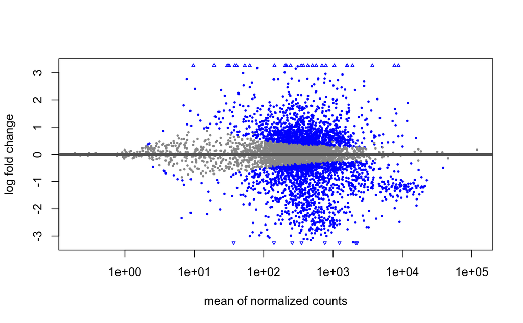

```r
plotMA(resLFC)
```

#### `limma-voom` analysis

Following [manual](https://www.bioconductor.org/packages/devel/bioc/vignettes/limma/inst/doc/usersguide.pdf#page=71.16)

```r
group <- samples_to_use[colnames(cts_sub), "Timepoint"] %>% droplevels()
design <- model.matrix(~ group)
dge <- DGEList(counts = cts_sub, group = group)
keep <- filterByExpr(dge)
dge <- dge[keep, , keep.lib.sizes=FALSE]
dge <- calcNormFactors(dge)
```

voom transformation

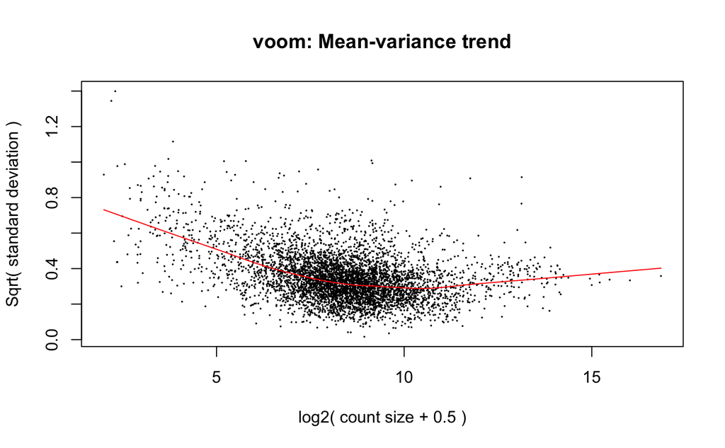

```r
v <- voom(dge, design, plot=TRUE)
```

DGE

```r
fit <- lmFit(v, design)
fit <- treat(fit, lfc = 1)
res_limma <- topTreat(fit, coef="group20m", number = Inf, sort.by = "P")
summary(res_limma)
```

```
     logFC             AveExpr               t              P.Value
 Min.   :-4.80756   Min.   :-0.09295   Min.   :-16.601   Min.   :0.0000
 1st Qu.:-0.47253   1st Qu.: 5.38706   1st Qu.:  0.000   1st Qu.:0.6787
 Median : 0.01290   Median : 6.31469   Median :  0.000   Median :0.9982
 Mean   :-0.04402   Mean   : 6.29981   Mean   : -0.287   Mean   :0.7647
 3rd Qu.: 0.45592   3rd Qu.: 7.23701   3rd Qu.:  0.000   3rd Qu.:0.9999
 Max.   : 9.43627   Max.   :14.75502   Max.   : 37.783   Max.   :1.0000
   adj.P.Val
 Min.   :0.0000014
 1st Qu.:1.0000000
 Median :1.0000000
 Mean   :0.8358100
 3rd Qu.:1.0000000
 Max.   :1.0000000
```

Summary stats

```r
attach(res_limma)
sprintf("lfc > 1: %i", sum(adj.P.Val < 0.05 & logFC > 1))
```

```
[1] "lfc > 1: 202"
```

```r
sprintf("lfc < -1: %i", sum(adj.P.Val < 0.05 & logFC < -1))
```

```
[1] "lfc < -1: 394"
```

```r
detach(res_limma)
```

#### Compare the two analyses

Combine their results

```r
deseq.res <- data.frame(name = rownames(res_deseq),
                        logFC = res_deseq$log2FoldChange,
                        padj = res_deseq$padj)
limma.res <- data.frame(name = rownames(res_limma),
                        logFC = res_limma$logFC,
                        padj = res_limma$adj.P.Val)
combine_res <- full_join(deseq.res, limma.res, by = "name",
                         suffix = c("_D", "_L"))
```

Plot comparison results

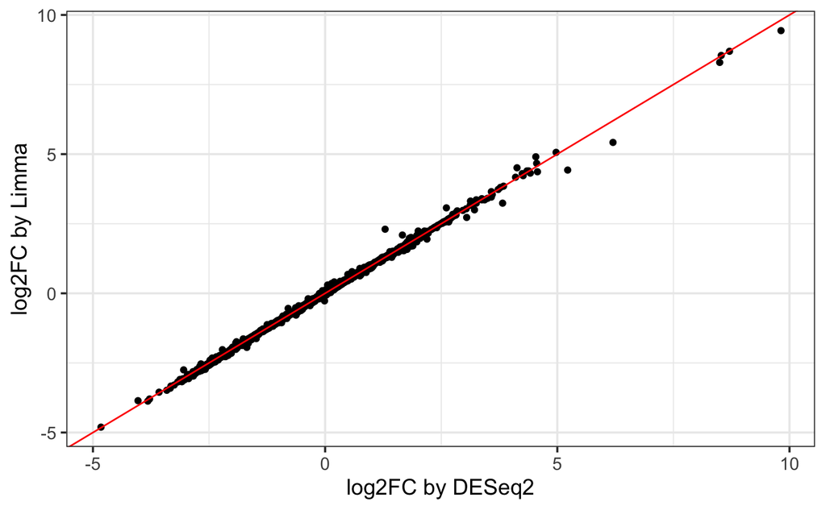

```r
ggplot(combine_res, aes(x = logFC_D, y = logFC_L)) +
  geom_point() + geom_abline(intercept = 0, slope = 1, color = "red") +
  xlab("log2FC by DESeq2") + ylab("log2FC by Limma")
```

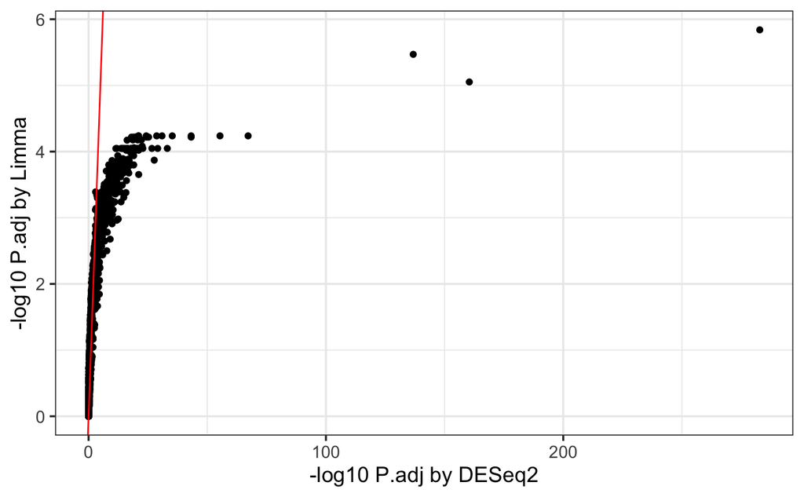

```r
ggplot(combine_res, aes(x = -log10(padj_D), y = -log10(padj_L))) +
  geom_point() + geom_abline(intercept = 0, slope = 1, color = "red") +
  xlab("-log10 P.adj by DESeq2") + ylab("-log10 P.adj by Limma")
```